# R Notebook zur explorativen Datenanalyse

Die explorative Datenanalyse findet hier statt.

```r
data <- readRDS("Comments_by_model.rds")
head(data)
```

```
## # A tibble: 6 x 4
##   text                                          submission comment_id topic
##   <chr>                                         <chr>      <chr>      <int>
## 1 "I like take home assignments more than leet~ jm38l7     gasoelz        3
## 2 As a Junior Data Scientist, give me a take h~ jm38l7     gasorok        3
## 3 [deleted]                                     jm38l7     gasp2fb        3
## 4 I always give feedback if asked and I think ~ jm38l7     gasp6kt        3
## 5 "I think that the \"\"work for free\"\" comp~ jm38l7     gasq7wq        3
## 6 "How is the interviewer doing unpaid work? \~ jm38l7     gasr4d4        3
```

Ein paar grundlegendende Summary-Statistiken sind an dieser Stelle notwendig. Schauen wir zuerst auf die Topic Verteilung:

```r
data %>%
  group_by(submission) %>%
  slice(1) %>%
  ungroup() %>%
  count()
```

```
## # A tibble: 1 x 1
##       n
##   <int>
## 1  5358
```

```r
data %>%
  filter(!is.na(topic)) %>%
  group_by(submission) %>%
  slice(1) %>%
  group_by(topic) %>%
  count(topic)
```

```
## # A tibble: 6 x 2
## # Groups:   topic [6]
##   topic     n
##   <int> <int>
## 1     1  1059
## 2     2   879
## 3     3  1146
## 4     4   556
## 5     5   705
## 6     6   984
```

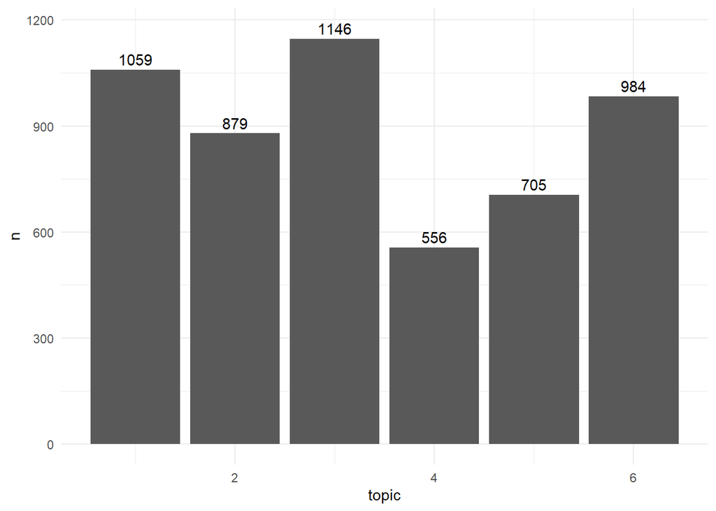

```r
data %>%
  filter(!is.na(topic)) %>%
  group_by(submission) %>%
  slice(1) %>%
  group_by(topic) %>%
  count(topic) %>%
  ggplot(aes(x=topic, y = n))+
  geom_col()+
  geom_text(aes(label=n), nudge_y = 30)+
  theme_minimal()
```

Wir haben also eine recht ausgeglichene Verteilung: Bei 5358 Threads haben wir mind. 556 Threads für ein Thema, 1146 ist hier die häufigste Ausprägung bei Thema 3. Versuchen wir die Topics mal mehr oder weniger thematisch einzuordnen.

```r
lda <- readRDS("LDA.rds")
lda_betas <- tidy(lda, matrix = "beta")
datatable(lda_betas %>%
  group_by(topic) %>%
  arrange(topic) %>%
  top_n(beta, n = 10)
, rownames = F)
```

| topic | term | beta |
| --- | --- | --- |
| 1 | c | 0.0289422808664067 |
| 1 | colleg | 0.0155278604463502 |
| 1 | engin | 0.0173623111020844 |
| 1 | job | 0.0270532334649661 |
| 1 | learn | 0.0156861910088987 |
| 1 | peopl | 0.0162157794422506 |
| 1 | program | 0.0165433599164888 |
| 1 | school | 0.0235208240177636 |
| 1 | softwar | 0.0129017569778736 |
| 1 | degre | 0.0253989520700629 |

[output cut: 50 more lines]

Als ersten Näherungsversuch sehe ich die Themen, die dort angesprochen werden, wie folgt: * Topic 1: c, engin, job, school, degre * C als Programmiersprache, engin* meint engineer, degree und school weißt insgesamt sehr darauf hin, dass es um die schulische Ausbildung und im weitesten Sinne der eigenen Karriere geht. Quasi um Fragen, die behandeln: Wie komme ich zu einem Software Engineer/developer Job? *Topic 2: compani, manag, peopl, team, time* compani ist sehr überbegrifflich, manag(er?) heißt ebenso wie people/team, dass es um die aktuelle Stelle und das Arbeitsklima und die Arbeitsbeziehung geht. Time ist ein sehr interessanter Punkt, der neben personellen Dingen (Manager/Team) eine Rolle spielt. *Topic 3: appli, compani, interview, job, offer* Relativ eindeutig: Hier geht es um den Bewerbungsprozess und dabei vermutlich eher um den ersten Teil, das Bewerben selbst, weniger um Details zur Anstellung. *Topic 4: dai, hour, job, life time* Schwierig zusammen zu fassen mit einem Oberbegriff, aber geht in die Richtung der Work-Life-Balance. Arbeitspensum (dai, hour, life) spielt hier eine Rolle und insgesamt scheint es das erste Mal um Themen zu gehen, die abseits der eigentlichen Arbeitsschwerpunkte gedacht werden. Im Sinne der Forschungsfrage kann dieses Topic vielversprechend sein. *Topic 5: compani, monei, pai, salari, tech* Es geht um Geld und zwar in drei Wegen: monei, pai, salari. Tech muss via Kookkurrenz herausgearbeitet werden. Das kann tech stack meinen, das kann aber auch oberbegrifflich gemeint sein. *Topic 6: code, develop, learn, project, test* code/develop/learn spricht sehr für das eigentliche coding, was thematisch schwer zu greifen ist. Learn ist im Sinne des Exzellenzanspruchs und der Innovation ein sehr interessantes Konstrukt. Test muss genauer zugeordnet werden.

Der erste Versuch die Themen zu benennen würde wie folgt lauten: *Topic 1: Ausbildung/Studium/Karriereweg* Topic 2: Arbeitsbeziehungen/Arbeitsklima/Zwischenmenschliche Beziehungen *Topic 3: Bewerbungen/Bewerbungsprozess/Jobsuche* Topic 4: Arbeit und Leben/Zeit/Pensum *Topic 5: Geld/Gehaltsverhandlungen* Topic 6: Weiterentwicklung/Coding/Lernen/Eigenbeschäftigung

Es ist also durchaus sinnvoll mal in einzelne Threads zu schauen. Schritt 1 wäre also die submission_ids herauszufiltern, die einen besonders hohen Theta-Wert (hier Gamma) für die jeweilige Kategorie aufweisen.

```r
lda_gammas <- tidy(lda, matrix = "gamma")

submission_titles <- readRDS("all_comments.rds")[,c(11,17),] %>%
  group_by(submission_id) %>%
  slice(1) %>%
  rename(document = submission_id)

lda_gammas <- left_join(lda_gammas, submission_titles)
#names(submission_titles)

datatable(lda_gammas %>%
  group_by(topic) %>%
  arrange(topic) %>%
  top_n(gamma, n = 5) %>%
  mutate(URL = paste0("reddit.com/", document))
  )
```

|  | document | topic | gamma | submission_title | URL |
| --- | --- | --- | --- | --- | --- |
| 1 | k6ljh5 | 1 | 0.755656108597285 | Co-op programs | reddit.com/k6ljh5 |
| 2 | k8solm | 1 | 0.751091703056769 | Should I also get a degree in mathematics besides computer science? | reddit.com/k8solm |
| 3 | kp4f5v | 1 | 0.758064516129032 | CS vs SE | reddit.com/kp4f5v |
| 4 | kxgns7 | 1 | 0.783783783783784 | Should I switch to Econ? | reddit.com/kxgns7 |
| 5 | l1r9h3 | 1 | 0.773654916512059 | Is Math and CS a good double degree? | reddit.com/l1r9h3 |
| 6 | ki7qae | 2 | 0.811897106109325 | How to behave with toxic Co-workers? | reddit.com/ki7qae |
| 7 | kufdy3 | 2 | 0.814814814814815 | Is this normal behaviour from senior people working in the IT field?[long] | reddit.com/kufdy3 |
| 8 | ky1bgd | 2 | 0.776 | All of my managers are female and show a clear bias against men | reddit.com/ky1bgd |
| 9 | l3s0g4 | 2 | 0.77326968973747 | Toxic lead developer | reddit.com/l3s0g4 |
| 10 | l5p1vx | 2 | 0.781609195402299 | Work environment turned sour | reddit.com/l5p1vx |

[output cut: 20 more lines]

- Topic 1: Bestätigt sich vollkommen. Die meisten Fragen sind in der Tat von Studenten, die nach Abschlüssen oder auch Studiengängen fragen.
- Topic 2: Der Eindruck bestätigt sich ebenso. Hier werden viele Nachfragen gestellt zu Arbeitsklima oder Beziehungen zu Vorgesetzten/Kollegen. Alle fünf Beispiele wirken eher negativ.
- Topic 3: Allgemeine Jobsuche und Bewerbungsprozess scheint zu stimmen. Der Eindruck, es gehe um wirkliche Bewerbungsgesräche, erhärtet sich nicht. Tendenziell geht es hier wohl eher um die wirkliche Jobsuche und die Frage “How to land a Job?”
- Topic 4: Die Zeit spielt ja in der Tat eine Rolle, auch in Bezug auf den Beruf, aber es geht hier vermehrt um Tipps, um das Arbeitsleben psychisch besser zu bewältigen. Wie kommen andere EntwicklerInnen runter, wie nehmen Sie sich eine Pause? Dabei spielt die always-on-Mentalität eine große Rolle. Auch die Pandemie ist mit Sicherheit ein Wirkfaktor. Darüber hinaus spielen Zeitnutzung und Zeit allgemein einen großen Faktor.
- Topic 5: Das Thema ist definitiv Geld, aber in einer Varianz an Schwerpunkten. Es geht zum einen um CoL (also Cost of Living), aber auch Stock Options, die als Teil der Kompensation gesehen werden.
- Topic 6: Anders als gedacht ist hier das Thema viel mehr der technische und operative Weg hin zu gewissen Sprachen/Expertisen etc. Was rein operativ anmutet, hat jedoch für die Innovations- und Ethik-Diskussion großen Mehrwert, da hier vor dem Hintergrund der notwendigen Scchritte und ggf. auch Aufopferung diskutiert wird. Bei der Frage “Wie werde ich XY?”, die implizit häufig gestellt wird, werden so Denkweisen und Erwartungshaltungen offen gelegt.

Die zweite Iteration der Themenzuordnung ergibt folgendes: *Topic 1: Ausbildung/Studium/Karriereweg/Studiengänge* Topic 2: Arbeitsbeziehungen/Arbeitsklima/Zwischenmenschliche Beziehungen *Topic 3: Bewerbungen/Bewerbungsprozess/Jobsuche* Topic 4: Arbeit und Leben/Zeit/Nicht-Arbeitszeit *Topic 5: Geld/Gehaltsverhandlungen/Finanzen/Aktien* Topic 6: Weiterentwicklung/Coding/Lernen/Eigenbeschäftigung/Sprachen

Dazu schauen wir uns in den Bereichen also nun mal so ein wenig die Kookkurrenzen an. Vorher muss aus dem Grunddatensatz ein Document-Term-Matrix gemacht werden.

Die Visualisierung sähe dann wie folgt aus. Hier sehen wir am Beispiel des Wortes “Tech” im Subkorpus 5, dass dieses Wort sich auf die Vielzahl an Bezeichnungen für Techfirmen und die Branche abzielt. Es ist von tech jobs, tech companies/giants/firms/scene/hub die Rede.

```
##             hubs            scene         industry             jobs
##        362.06796        275.64552        127.18931         85.24471
##          finance          workers     cutting_edge           giants
##         73.68160         68.87313         61.03352         60.46990
##            firms            world        companies         non-tech
##         55.79473         49.11224         48.53943         43.34965
##              top prior_experience            giant
##         42.35136         38.64422         32.27045
```

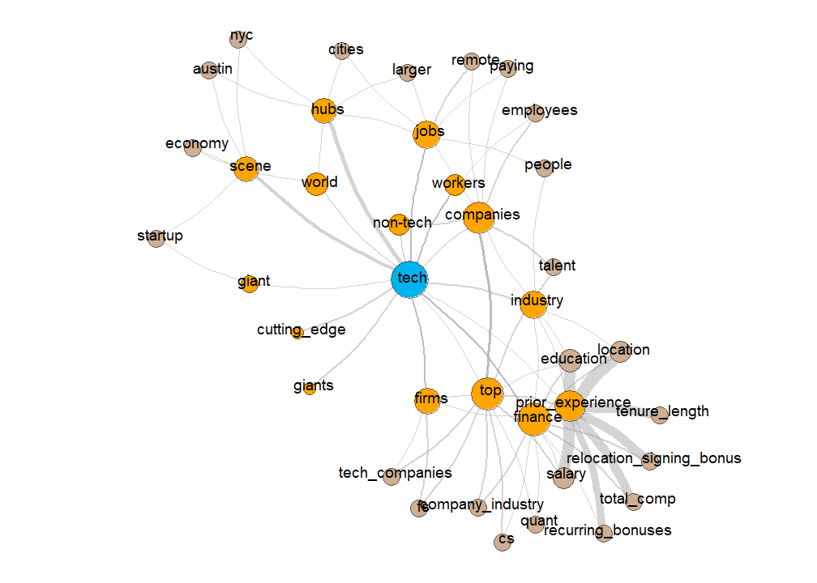

```r
source("plotCooc.R")

binDTM %>%
  dfm_subset(topic == 5) %>%
  plotCooc(n=15, "tech") # Gespeichert als Kook_T5_Tech
```

```r
#
# test <- corpus_sentences[which(grepl("faang", corpus_sentences, ignore.case = T))]
# kwic(x = .,pattern = phrase("prior experience"), window = 5 )
```

Anhand der Topics ist ersichtlich, welche Topics aus welchen Gründen sehr interessant für weitere Analysen sein können. Das Topic Vier beschäftigt sich fast ausschließlich mit dem Thema Zeit in verschiedenen Formen, während Topic 6 ausdrückt, dass die Weiterentwicklung, das Lernen, verschiedene Frameworks und Programmiersprachen eine Rolle spielen.

Ich möchte mir Topic 6 noch einmal genauer anschauen.

```r
datatable(lda_gammas %>%
  group_by(topic) %>%
  arrange(topic) %>%
  filter(topic == 6) %>%
  top_n(gamma, n = 50) %>%
  mutate(URL = paste0("reddit.com/", document))
  )
```

|  | document | topic | gamma | submission_title | URL |
| --- | --- | --- | --- | --- | --- |
| 1 | jngnqq | 6 | 0.7 | What data analysis project could I create to be attractive in data analysis/reporting market ? | reddit.com/jngnqq |
| 2 | jop6ja | 6 | 0.67175572519084 | I haven't written tests for my code before. How do I learn proper form for unit testing and automating them? | reddit.com/jop6ja |
| 3 | jpcri7 | 6 | 0.64963503649635 | Not sure if programming or devops job? | reddit.com/jpcri7 |
| 4 | jsf4ll | 6 | 0.67065868263473 | Self-taught programmer. What should I learn before applying for jobs? | reddit.com/jsf4ll |
| 5 | jshua9 | 6 | 0.668122270742358 | How important is it to know JavaScript? | reddit.com/jshua9 |
| 6 | ju6igt | 6 | 0.741379310344828 | Learning Programming George Hotz Way | reddit.com/ju6igt |
| 7 | juf4so | 6 | 0.821276595744681 | Backend engineering career | reddit.com/juf4so |
| 8 | julwvp | 6 | 0.681564245810056 | What do you predict for the future of React in the next 5 years? | reddit.com/julwvp |
| 9 | jvd0y3 | 6 | 0.718918918918919 | Is ""app developer"" a real job? Is it more or less common than web developer? | reddit.com/jvd0y3 |
| 10 | jyica2 | 6 | 0.661538461538462 | Web developer or data analyst | reddit.com/jyica2 |

[output cut: 40 more lines]

Nachdem ein Großteil der Inhalte des Topic 6 angeschaut wurde, lässt sich hier zusammenfassen: Es geht um Operatives und Entwicklung. Inhalte sind hier sehr nah an Sprachen und an Entwicklungen hin zu gewissen Positionen/Spezifizierungen, um die Verbesserung des eigenen “Status” durch eigene Projekte oder Leetcode. Beides ist sehr interessant, insb. ggf. für die Forschungsfrage 3. Auf der anderen Seite gibt es sehr technische Fragen, die nichts mit der Berufswelt zu tun hat, sondern genau genommen technische Fragen sind (kkrh2d, kn7rb3).

Damit steht aber trotzdem fest, dass Topic ein sehr interessantes Topic ist, das untersucht werden wird. Topic 3 wird für Bewerbungsprozesse interessant sein, hier sehe ich Potenzial für Frage 4, während Topic 5 im weitesten Sinne als Vergleich zur Hacker Ethik angeschaut werden kann. Am ehesten, und damit geht es mit der Forschungsfrage 2 los, sind Arbeitsethik-Diskurse in Thema 4, 6 oder 5 zu vermuten.

Angesichts der Topic-bestimmenden Worte liegt es nahe, sich das Thema Zeit genauer anzusehen, da dies Teil der Arbeitsethik und des Selbstverständnisses ist, aber auch hier sehr sehr prominent diskutiert wird. Darüber hinaus spielt Lernen eine größere Rolle, die es zu untersuchen gilt.

Was sehen wir also beim Thema Zeit in Topic 4?

```
##     spend     spent     waste   wasting  spending    taking     spare
## 393.86570 219.72275 138.16850 106.95616 105.45640 100.27055  88.79527
##    amount    period    crunch     takes   periods       lot     hours
##  84.62410  73.63435  65.80655  65.47239  61.93191  60.71534  59.07165
##     extra
##  55.02274
```

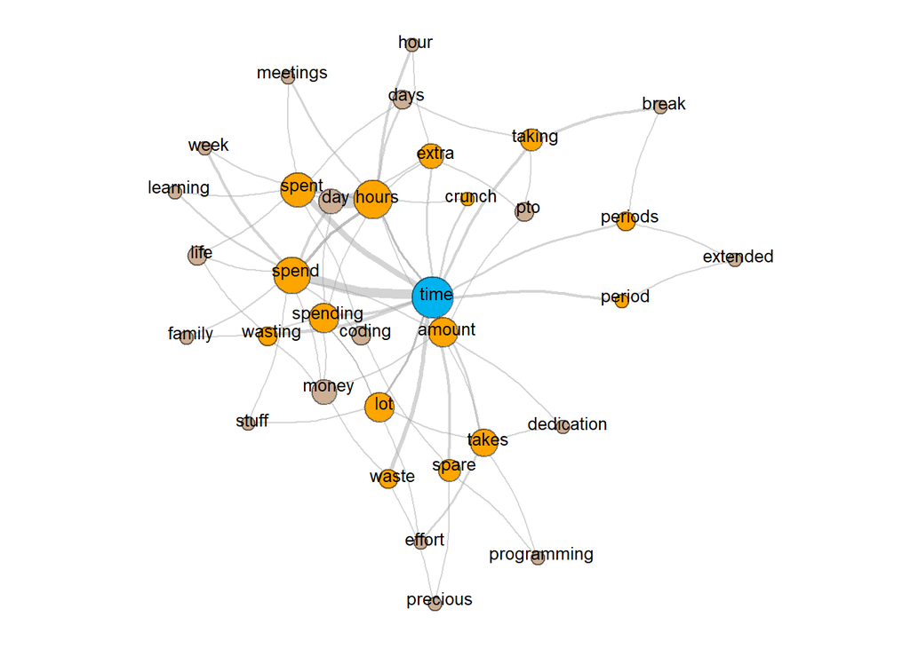

```r
binDTM %>%
  dfm_subset(topic == 4) %>%
  plotCooc(n=15, "time")
```

```r
corpus_sentences_t4 <- corpus_subset(cscq_corpus, topic == 4)


datatable(corpus_subset(corpus_sentences_t4, grepl("time", corpus_sentences_t4, ignore.case = T)) %>%
  kwic(x = .,pattern = "spare", window = 10 ))
```

|  | docname | from | to | pre | keyword | post | pattern |
| --- | --- | --- | --- | --- | --- | --- | --- |
| 1 | gb8tiq7 | 90 | 90 | into perspective . I enjoy programming . I like spending | spare | time on becoming a better engineer . I just don't | spare |
| 2 | gc45aw0 | 70 | 70 | outside of work . A chef that cooks in their | spare | time will probably do better than one that hates cooking | spare |
| 3 | gc473yu | 47 | 47 | truly enjoy reading blogs / books about programming in your | spare | time than go for it . If you don't I | spare |
| 4 | gcfg4pj | 130 | 130 | woodworking , reading , hiking , and fishing in my | spare | time and those give me enough purpose . If you're | spare |
| 5 | gcu9bnd | 133 | 133 | I still love programming and I do programming in my | spare | time . I've been doing leetcode stuff at the moment | spare |
| 6 | gdm8lpm | 748 | 748 | at all times with projects and we have very little | spare | time &gt; How hard would you have to work as | spare |
| 7 | gegrjh3 | 198 | 198 | my work and read tech blogs / program in my | spare | time sometimes , but it's not the focus of my | spare |
| 8 | gegtdao | 87 | 87 | with . . Just look for diff jobs in your | spare | time . | spare |
| 9 | gej8vci | 110 | 110 | programming you do when you're just making something in your | spare | time . Working for myself was also pretty cool . | spare |
| 10 | geqffti | 199 | 199 | don't mind learning and working on new things in your | spare | time you'll be fine . Hell , if the pay | spare |

[output cut: 17 more lines]

```r
quanteda::corpus_subset(corpus_sentences, comment_id== "gc45aw0") # Zitat für den Impetus der Nutzung von Freizeit.
```

```
## Corpus consisting of 7 documents and 4 docvars.
## gc45aw0.1 :
## "It certainly doesn't apply to everyone, but I would say that..."
##
## gc45aw0.2 :
## "They are just treating it like any other job."
##
## gc45aw0.3 :
## "Some of the best people in any career are the ones that enjo..."
##
## gc45aw0.4 :
## "A chef that cooks in their spare time will probably do bette..."
##
## gc45aw0.5 :
## "A mechanic that tinkers with their car on their free time wi..."
##
## gc45aw0.6 :
## "An artist that only paints at work probably won't be as good..."
##
## [ reached max_ndoc ... 1 more document ]
```

```
##      spend       code     coding      enjoy   projects    hobbies
##   44.09925   38.78315   23.48263   20.78611   18.14833   15.61729
##    passion   obsolete     rarely   employer   weekends assumption
##   14.70151   13.16493   12.53735   12.44551   11.63065   10.90080
## overworked      hobby       wont
##   10.90080   10.35019   10.23106
```

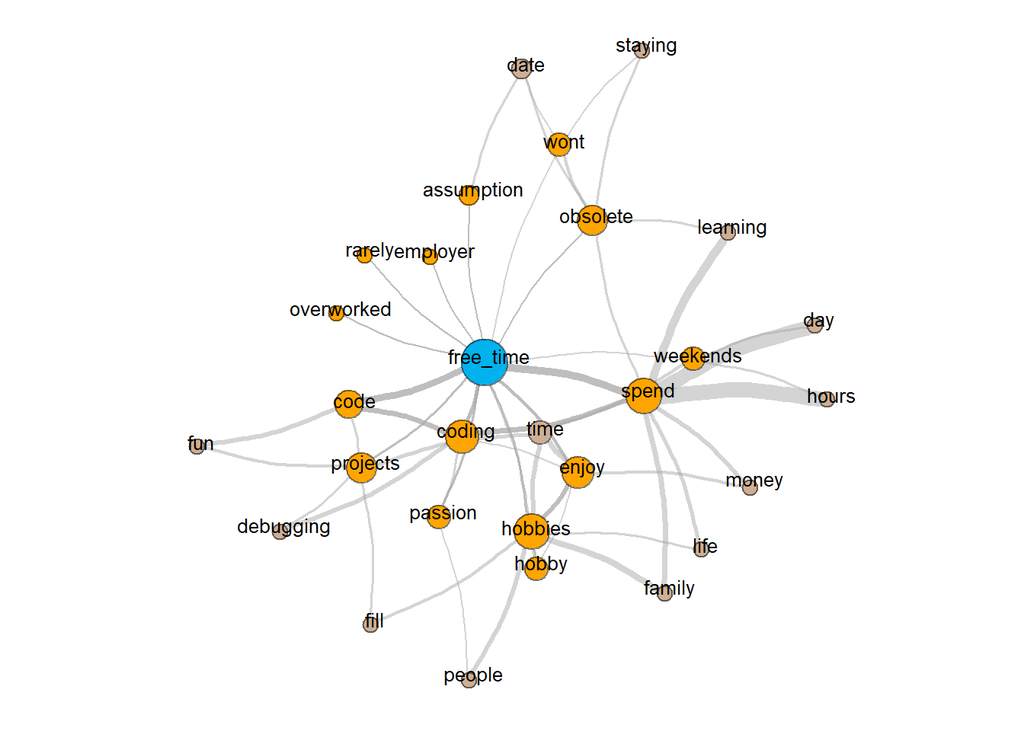

```r
binDTM %>%
  dfm_subset(topic == 4) %>%
  plotCooc(n=15, "free_time")
```

```r
datatable(cscq_collocations)
```

|  | collocation | count | count_nested | length | lambda | z |
| --- | --- | --- | --- | --- | --- | --- |
| 1 | software engineer | 958 | 0 | 2 | 6.12808178338812 | 145.795221174152 |
| 2 | software engineering | 832 | 0 | 2 | 6.16497162919825 | 136.726337220717 |
| 3 | computer science | 707 | 0 | 2 | 8.60168338396527 | 134.14591654279 |
| 4 | cs degree | 723 | 0 | 2 | 5.44889725410262 | 124.012703573681 |
| 5 | entry level | 1128 | 0 | 2 | 8.86804959736807 | 121.785726610946 |
| 6 | software development | 613 | 0 | 2 | 5.81379865441431 | 117.402428268264 |
| 7 | data science | 406 | 0 | 2 | 6.57926963685342 | 105.286461153558 |
| 8 | makes sense | 353 | 0 | 2 | 6.82131944126961 | 102.256075529605 |
| 9 | web dev | 378 | 0 | 2 | 6.18048989713165 | 100.166271776223 |
| 10 | mental health | 333 | 0 | 2 | 9.48759877127835 | 98.159366494929 |

[output cut: 240 more lines]

```
##        github      projects   internships      leetcode    experience
##      78.87414      77.32206      75.24076      67.71800      52.64451
##     free_time        resume        school        skills          time
##      50.54412      50.33257      43.75538      27.85191      26.28686
##         spend           gpa    recruiters self-learning        grades
##      26.24279      23.21572      22.30230      20.84082      20.81955
```

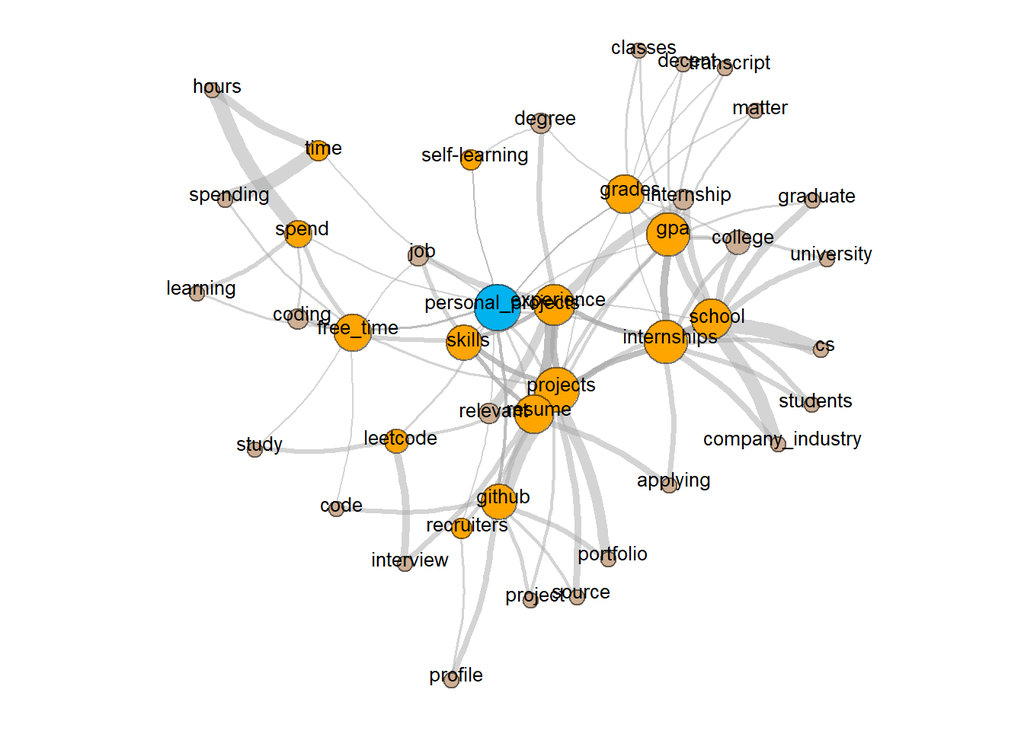

```r
binDTM %>%
  plotCooc(n=15, "personal_projects")
```

Blicken wir eine Ebene tiefer, das heißt in den Bereich der Inhalte der freizeitlichen Auseinandersetzung, dann geht es um Lernen, Weiterentwicklung und Beitragen (contribute).Diese Off-Time Zeit mit den beruflichen Inhalten wird häufig via Persönlicher Projekte (personal Projects) ausgelebt. In der Kookkurenzanalyse dieser Kollokation sind weitere arbeitsethische Inhalte wiederzufinden. Zum einen ist anhand der Nähe zum Thema Freizeit klar, in welchem Umfang diese Tätigkeiten ausgeübt werden, zum anderen wird schnell erkenntlich, was das Ziel dieser persönlichen Projekte ist:

Zum einen ist die Erfahrung, die solche Projekte bringen, offensichtlich nicht von der Hand zu weisen, aber die semantische Nähe zur Bewerbung, zu Fähigkeiten, zum Praktikum und zu Personalern macht deutlich, dass diese persönlichen Projekte durchgeführt werden, um sich stetig weiter zu entwickeln und somit im Berufsmarkt voran zu kommen. Hier sind wir weniger im deutenden Bereich der Branche als im beschreibenden Bereich unterwegs, da hier keine Wertung zum Thema personal projects vorhanden ist. Insofern ist dieser Einblick aber bezeichnend für die Arbeitsweise und für die Grundprinzipien, die bei EntwicklerInnen und solchen, die es werden wollen, vorhanden sind: Die Auseinandersetzung mit beruflichen Inhalten sind nicht nur förderlich, sondern notwendig, da sie nicht nur die Fähigkeiten erhöhen, sondern die Chancen, sich auf dem Berufsmarkt zu behaupten. Was hier passiert, ist beeindruckend: Aus einem ethischen Prinzip der Hacker Ethik, das ausgibt, sich an Open Source-Projekten zu beteiligen, wurde nicht einmal ein Wettbewerbsvorteil im Berufsmarkt, sondern gar eine Notwendigkeit des Arbeitsmarkt von SoftwareentwicklerInnen. Das bedeutet, dass es nicht nur um die Erweiterung der Fähigkeiten aus Grund des eigenen Exzellenzstrebens geht, sondern um die Notwendigkeit, als Softwareentwickler zu bestehen und sich durchzusetzen.

```r
datatable(corpus_sentences %>%
  kwic(x = .,pattern = phrase("personal projects"), window = 10 ))
```

|  | docname | from | to | pre | keyword | post | pattern |
| --- | --- | --- | --- | --- | --- | --- | --- |
| 1 | gat9wqd.1 | 14 | 15 | paid to do opensource stuff and a lot of my | personal projects | are closed source . | personal projects |
| 2 | gawajto.3 | 4 | 5 | This is on | personal projects | . | personal projects |
| 3 | gawce46.2 | 23 | 24 | real slog for me , but doing automation programming and | personal projects | are my happy place . | personal projects |
| 4 | gaxj469.1 | 15 | 16 | , I do the same stuff for fun but as | personal projects | . | personal projects |
| 5 | gayh0tn.5 | 12 | 13 | you don't need the money , work on open-source or | personal projects | . | personal projects |
| 6 | gayqwoe.2 | 54 | 55 | program and just focus on software electives and do software | personal projects | and software school organizations etc . ( and vice versa | personal projects |
| 7 | gb0a23r.3 | 31 | 32 | with leetcode problems or if I should focus on doing | personal projects | to build my resume up instead . | personal projects |
| 8 | gb0xxoz.2 | 3 | 4 | Work on | personal projects | or Do something on kaggle or online code contests . | personal projects |
| 9 | gb114ui.2 | 36 | 37 | can do something , but they have no authority over | personal projects | . | personal projects |
| 10 | gb196aw.4 | 10 | 11 | Something you may want to consider doing is doing | personal projects | , either in data engineering or web development , to | personal projects |

[output cut: 331 more lines]

Was insbesondere im Lern-Bereich auffällt ist, dass viele Fragen in die Richtung Career-Advice gehen und nach Rat gefragt wird. Hier sind die Ratschläge, die häufig für die Entwicklung persönlicher Projekte sprechen, zumeist sehr direkt und auffordernd. Die Wortwahl ist dabei “You should”, “Start Working” etc.

Insofern kann zwischenzeitlich resümiert werden, dass arbeitsethische Diskurse bedeutend stark in die Richtung von Zeit und Zeitnutzung gehen, das bedeutet, dass es eine Prinzipienordnung für Freizeit gibt und wie diese zu werten ist. Auf der anderen Seite steht überall das Thema Lernen im Mittelpunkt und Weiterentwicklung im Mittelpunkt, das schlussendlich aber das Ziel der Employability hat.

Wie sieht es mit Geld aus? Und welche Ethik-Bereiche gibt es noch?